# Evidencia 2

Edrick Galicia Villanueva - A01662660

2022-04-27

PARTE 2: 1. De las siguientes tres opciones, selecciona una opción para investigar: Opcion Elegida: A a) Analizar las secuencias de SARS-CoV-2 reportadas en los 20 países con más casos reportados. Y puedes tratar de responder a la pregunta: ¿Son muy diferentes las variantes entre cada país? ¿Es diferente el SARS-CoV-2 entre las diferentes poblaciones: Asiática, Hispana, Europea o Africana?

```r
#Paquetes y fastas por pais de primero al ultimo en casos activos actuales.

library("seqinr")

Alemania1 <- read.fasta("Alemania.fasta")
SouthKorea2 <- read.fasta("SKorea.fasta")
Francia3 <- read.fasta("Francia.fasta")
Italia4 <- read.fasta("Italia.fasta")
US5 <- read.fasta("USA.fasta")
Australia6 <- read.fasta("Australia.fasta")
Japon7 <- read.fasta("Japan.fasta")
China8 <- read.fasta("China.fasta")
Vietnam9 <- read.fasta("Vietnam.fasta")
UK10 <- read.fasta("UnitedKingdom.fasta")
Tailandia11 <- read.fasta("Tailandia.fasta")
Brasil12 <- read.fasta("Brasil.fasta")
Espana13 <- read.fasta("Spain.fasta")
Rusia14 <- read.fasta("Rusia.1.fasta")
Canada15 <- read.fasta("Canada.fasta")
Portugal16 <- read.fasta("Portugal.fasta")
NZelanda17 <- read.fasta("NuevaZelanda.fasta")
Austria18 <- read.fasta("Austria.fasta")
Grecia19 <- read.fasta("Grecia.fasta")
Belgica20 <- read.fasta("Belgica.fasta")
```

2. Calcula el número de bases de cada secuencia que incluyas.

```r
length(Alemania1[[1]])
```

```
## [1] 29431
```

```r
length(SouthKorea2[[1]])
```

```
## [1] 29699
```

```r
length(Francia3[[1]])
```

```
## [1] 29729
```

```r
length(Italia4[[1]])
```

```
## [1] 29608
```

```r
length(US5[[1]])
```

```
## [1] 29755
```

```r
length(Australia6[[1]])
```

```
## [1] 28815
```

```r
length(Japon7[[1]])
```

```
## [1] 29703
```

```r
length(China8[[1]])
```

```
## [1] 29662
```

```r
length(Vietnam9[[1]])
```

```
## [1] 29782
```

```r
length(UK10[[1]])
```

```
## [1] 29769
```

```r
length(Tailandia11[[1]])
```

```
## [1] 29652
```

```r
length(Brasil12[[1]])
```

```
## [1] 29762
```

```r
length(Espana13[[1]])
```

```
## [1] 29748
```

```r
length(Rusia14[[1]])
```

```
## [1] 29741
```

```r
length(Canada15[[1]])
```

```
## [1] 29724
```

```r
length(Portugal16[[1]])
```

```
## [1] 29720
```

```r
length(NZelanda17[[1]])
```

```
## [1] 29652
```

```r
length(Austria18[[1]])
```

```
## [1] 2403
```

```r
length(Grecia19[[1]])
```

```
## [1] 29602
```

```r
length(Belgica20[[1]])
```

```
## [1] 29783
```

```r
library("seqinr")
library("ggplot2")
library(Biostrings)
library(seqinr)
library(adegenet)
library(ape)
library(ggtree)
library(DECIPHER)
library(viridis)
library(ggplot2)
```

3. Crea una sola gráfica donde se comparen el número de bases de ADN que componen todas las variantes del virus.

```r
library("tidyverse")
```

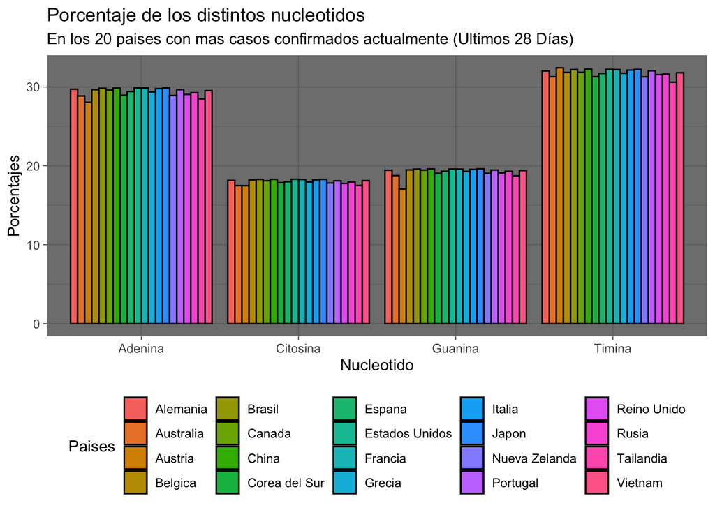

```r
porcentaje <- function(dna){
  contadorA<-contadorT<-contadorC<-contadorG<-0
  largo <- length(dna)
  for(i in 1:largo){
    if(dna[i] == "a"){
      contadorA <- contadorA +1
    }
    else if(dna[i] == "t"){
      contadorT <- contadorT +1
    }
    else if(dna[i] == "c"){
      contadorC <- contadorC +1
    }
    else if(dna[i] == "g"){
      contadorG <- contadorG +1
    }
  }
  porc <- c("%A"=(contadorA/largo)*100, "%T"=(contadorT/largo)*100, "%C"=(contadorC/largo)*100, "%G"=(contadorG/largo)*100)
  return(porc)
}

AlemaniaPor <- porcentaje(Alemania1[[1]])
SouthKoreaPor <- porcentaje(SouthKorea2[[1]])
FranciaPor <- porcentaje(Francia3[[1]])
ItaliaPor <- porcentaje(Italia4[[1]])
USPor <- porcentaje(US5[[1]])
AustraliaPor <- porcentaje(Australia6[[1]])
JaponPor <- porcentaje(Japon7[[1]])
ChinaPor <- porcentaje(China8[[1]])
VietnamPor <- porcentaje(Vietnam9[[1]])
UKPor <- porcentaje(UK10[[1]])
TailandiaPor <- porcentaje(Tailandia11[[1]])
BrasilPor <- porcentaje(Brasil12[[1]])
EspanaPor <- porcentaje(Espana13[[1]])
RusiaPor <- porcentaje(Rusia14[[1]])
CanadaPor <- porcentaje(Canada15[[1]])
PortugalPor <- porcentaje(Portugal16[[1]])
NzelandaPor <- porcentaje(NZelanda17[[1]])
AustriaPor <- porcentaje(Austria18[[1]])
GreciaPor <- porcentaje(Grecia19[[1]])
BelgicaPor <- porcentaje(Belgica20[[1]])

Paises <- c(rep(c("Alemania"), 4), rep(c("Corea del Sur"), 4), rep(c("Francia"), 4), rep(c("Italia"), 4), rep(c("Estados Unidos"), 4), rep(c("Australia"), 4), rep(c("Japon"), 4), rep(c("China"), 4), rep(c("Vietnam"), 4), rep(c("Reino Unido"), 4), rep(c("Tailandia"), 4), rep(c("Brasil"), 4), rep(c("Espana"), 4), rep(c("Rusia"), 4), rep(c("Canada"), 4), rep(c("Portugal"), 4), rep(c("Nueva Zelanda"), 4), rep(c("Austria"), 4), rep(c("Grecia"), 4), rep(c("Belgica"), 4))

Nucleotido <- rep(c("Adenina", "Timina", "Citosina", "Guanina"), 5)

Grafica <- data.frame(Paises, Nucleotido,
                      Porcentajes = c(AlemaniaPor,
                                      SouthKoreaPor,
                                      FranciaPor,
                                      ItaliaPor,
                                      USPor,
                                      AustraliaPor,
                                      JaponPor,
                                      ChinaPor,
                                      VietnamPor,
                                      UKPor,
                                      TailandiaPor,
                                      BrasilPor,
                                      EspanaPor,
                                      RusiaPor,
                                      CanadaPor,
                                      PortugalPor,
                                      NzelandaPor,
                                      AustriaPor,
                                      GreciaPor,
                                      BelgicaPor))

ggplot(data = Grafica, aes(x = Nucleotido, y = Porcentajes,
                           fill = Paises)) +
  geom_bar(stat = "identity", position = "dodge", color = "black") +
  labs(title = "Porcentaje de los distintos nucleotidos",
       subtitle = "En los 20 paises con mas casos confirmados actualmente (Ultimos 28 Días)")  +
  theme_dark() +
  theme(legend.position = "bottom")
```